# Wine Quality Prediction

## Introduction

### Abstract

Wine making is an intricate process, with many chemical and physical variables influencing the quality and taste of the final product. According to the Grand View Research the United States wine market size was estimated at $63.69 billion in 2021. As wine consumers ourselves, our team wanted to better understand the key drivers of wine quality using data-driven techniques.

Prior studies have examined the chemical properties of wines, but few have conducted extensive statistical analysis to relate these properties to overall quality ratings from wine experts. Our goal was to bridge this gap using exploratory data analysis and statistical modeling.

The analysis will shed light on the factors that contribute to the quality of both red and white wines. It will examine the various chemical components that make up each type of wine. These ingredients each have a distinct relationship with the resulting character of the red or white wine. Understanding these relationships is valuable for wine drinkers who have preferences for certain styles of wine.

### Why we chose this topic?

We believe that our efforts to decipher the complex relationship between wine quality and its chemical makeup will be extremely beneficial to wine producers and distributors. This research provides winemakers with crucial assistance to develop wines that have the required characteristics. With a better knowledge of how elements like density, chlorides, and other elements affect wine quality, they may improve their manufacturing methods so that they constantly meet and surpass consumer expectations.

The consumer can also benefit from this analysis. They can understand which ingredients make the quality better and can ask for those wines. They will also understand if the price they’re paying is commensurate with the quality.

## Data Description

The dataset includes two tables, one for the red wine and one for the white wine. All of the variables in both datasets are synonymous, thus only one data understanding table was constructed. The exact number of columns and rows for each table (type of wine) is included below:

Wine quality-red 12 columns x 1,599 rows

Wine quality-white 12 columns x 4,898 rows

Head

| type | fixed.acidity | volatile.acidity | citric.acid | residual.sugar | chlorides | free.sulfur.dioxide | total.sulfur.dioxide | density | pH | sulphates | alcohol | quality |
| --- | --- | --- | --- | --- | --- | --- | --- | --- | --- | --- | --- | --- |
| white | 7.0 | 0.27 | 0.36 | 20.7 | 0.045 | 45 | 170 | 1.001 | 3.00 | 0.45 | 8.8 | 6 |
| white | 6.3 | 0.30 | 0.34 | 1.6 | 0.049 | 14 | 132 | 0.994 | 3.30 | 0.49 | 9.5 | 6 |
| white | 8.1 | 0.28 | 0.40 | 6.9 | 0.050 | 30 | 97 | 0.995 | 3.26 | 0.44 | 10.1 | 6 |
| white | 7.2 | 0.23 | 0.32 | 8.5 | 0.058 | 47 | 186 | 0.996 | 3.19 | 0.40 | 9.9 | 6 |
| white | 7.2 | 0.23 | 0.32 | 8.5 | 0.058 | 47 | 186 | 0.996 | 3.19 | 0.40 | 9.9 | 6 |

The different columns present are:

**Categorical Variable**

1. Type - Colour of wine [ Red or White]

**Numerical Variables**

2. Fixed Acidity - Concentration of non-volatile tartaric acid in the wine
3. Volatile Acidity - Concentration of volatile acetic acid in the wine.
4. Citric Acid - Concentration of citric acid in the wine.
5. Residual Sugar - Concentration of sugar remaining after the fermentation in the wine.
6. Chlorides - Concentration of sodium chloride in the wine.
7. Free Sulfur Dioxide - Concentration of free, gaseous sulfur dioxide in the wine.
8. Total Sulfur Dioxide - Total concentration of sulfur dioxide in the wine.
9. Density - Density of the wine.
10. pH - Acidity of the wine.
11. Sulphates - Concentration of potassium sulfate in the wine.
12. Alcohol - Alcohol content of the wine.

**Target Variable**

13. Quality - Wine quality score as assessed by experts.

We use quality as our base factor and have constructed our analysis around. The Quality ranges from 3 - 9, where *3 - Bad Qualtiy* and *9 - Good Quality* and all that is in between is said to be *Average Quality* wine!

## Research Questions - SMART QUESTIONS!

1. Which chemical attribute has the most **significant** influence on wine quality?
2. How does the distribution of sugar, sulfate, chloride, pH, and alcohol content change over **different quality categories**?
3. From the above analysis how is it **different between red and white wine?**

The target variable for our research project is : **QUALITY**

## Evolution of Questions

Before we began with our analysis as a data scientists, we questioned ourselves based on our previous experiences of having tasted wine that in general what would effect the overall quality. We summarized that maybe the amount of alcohol present would effect it or the sweetness of the wine, or maybe even the acidity could be an influential factor. Keeping these thoughts in mind we wanted to see if our initial assumptions were true or were we going to find something more interesting through our analysis and also determine to what extent these factors effect the quality!

## Data Cleaning

The data which we have right now is in unclean. Meaning that there are a lot of NA values and duplicates. The first step of any data science project is to clean the data.

Right now, we have **6497 rows and 13 variables.**

Steps to clean the data:

1. Remove NA values
2. Remove duplicate values.

The clean data has **5295 rows and 13 variables**. It is free from NA values and duplicates and now can be used for further exploratory data analysis.

## Summary Statistics

Now, that we have a completely clean data lets look at the summary statistics of the dataset.

Table: Statistics summary.

|  | type | fixed.acidity | volatile.acidity | citric.acid | residual.sugar | chlorides | free.sulfur.dioxide | total.sulfur.dioxide | density | pH | sulphates | alcohol | quality |
| --- | --- | --- | --- | --- | --- | --- | --- | --- | --- | --- | --- | --- | --- |
| Min | Length:5295 | Min. : 3.80 | Min. :0.080 | Min. :0.000 | Min. : 0.6 | Min. :0.009 | Min. : 1 | Min. : 6 | Min. :0.987 | Min. :2.72 | Min. :0.220 | Min. : 8.0 | Min. :3.0 |
| Q1 | Class :character | 1st Qu.: 6.40 | 1st Qu.:0.230 | 1st Qu.:0.240 | 1st Qu.: 1.8 | 1st Qu.:0.038 | 1st Qu.: 16 | 1st Qu.: 74 | 1st Qu.:0.992 | 1st Qu.:3.11 | 1st Qu.:0.430 | 1st Qu.: 9.5 | 1st Qu.:5.0 |
| Median | Mode :character | Median : 7.00 | Median :0.300 | Median :0.310 | Median : 2.7 | Median :0.047 | Median : 28 | Median :116 | Median :0.995 | Median :3.21 | Median :0.510 | Median :10.4 | Median :6.0 |
| Mean | NA | Mean : 7.22 | Mean :0.344 | Mean :0.319 | Mean : 5.1 | Mean :0.057 | Mean : 30 | Mean :114 | Mean :0.995 | Mean :3.22 | Mean :0.533 | Mean :10.6 | Mean :5.8 |
| Q3 | NA | 3rd Qu.: 7.70 | 3rd Qu.:0.410 | 3rd Qu.:0.400 | 3rd Qu.: 7.5 | 3rd Qu.:0.066 | 3rd Qu.: 41 | 3rd Qu.:154 | 3rd Qu.:0.997 | 3rd Qu.:3.33 | 3rd Qu.:0.600 | 3rd Qu.:11.4 | 3rd Qu.:6.0 |
| Max | NA | Max. :15.90 | Max. :1.580 | Max. :1.660 | Max. :65.8 | Max. :0.611 | Max. :289 | Max. :440 | Max. :1.039 | Max. :4.01 | Max. :2.000 | Max. :14.9 | Max. :9.0 |

Our next step is to visualize these using plots.

## Exploratory Data Analysis (EDA)

## Univariate Analysis

### **1. Quality**

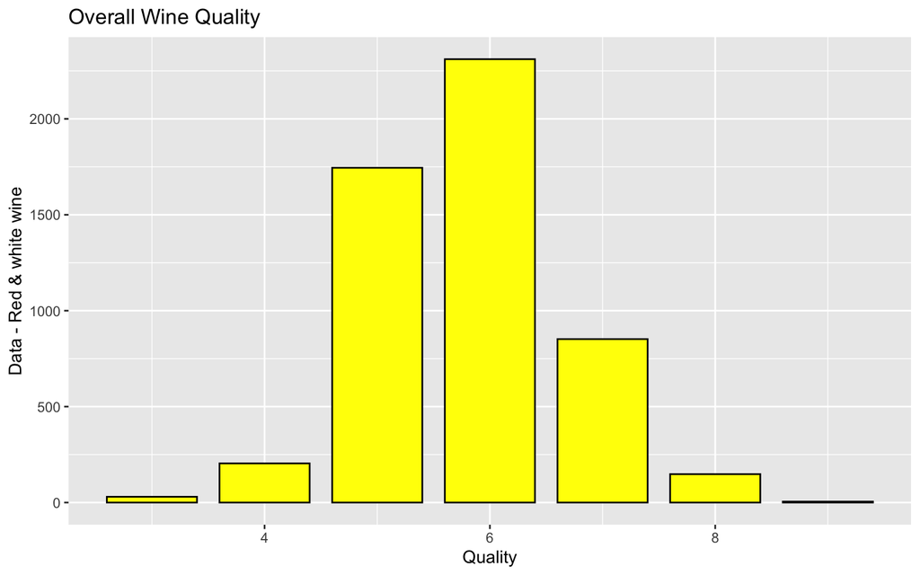

**Observations**

1. Wine quality shows a rather **symmetrical distribution.**
2. Most wines have a **quality score of 6.**
3. No wine achieved the highest score of 10 and the worst wines got a rating of 3.

### **2. Acidity**

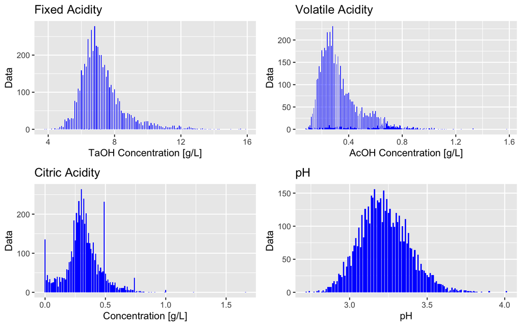

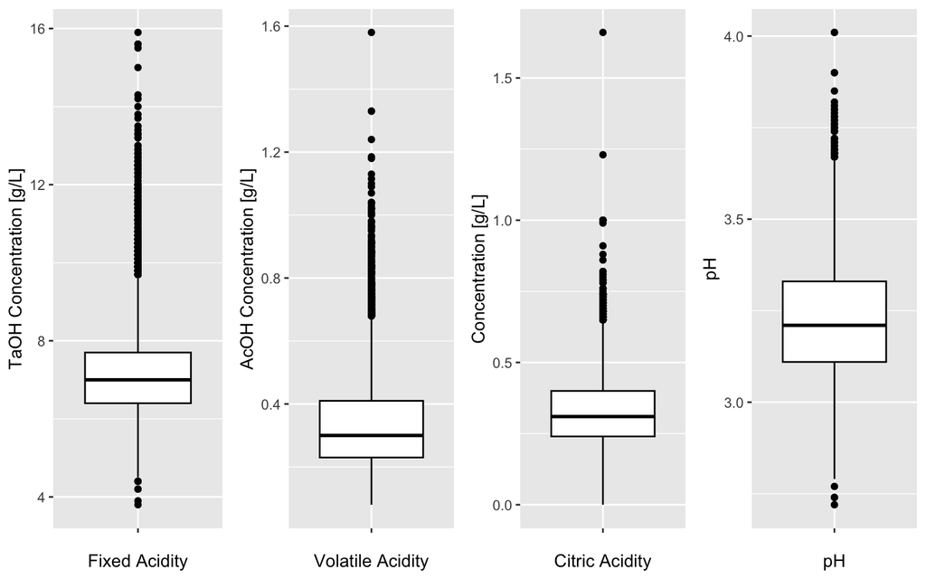

**Observations**

1. Looking at the acidity parameters in boxplots gives a similar picture. One can see the long positive tails of fixed and volatile acide concentrations.
2. Citric Acid has a **bimodal distribution.**
3. The pH level of wines has a normal distribution with median of 3.2

### **3. Sulphates**

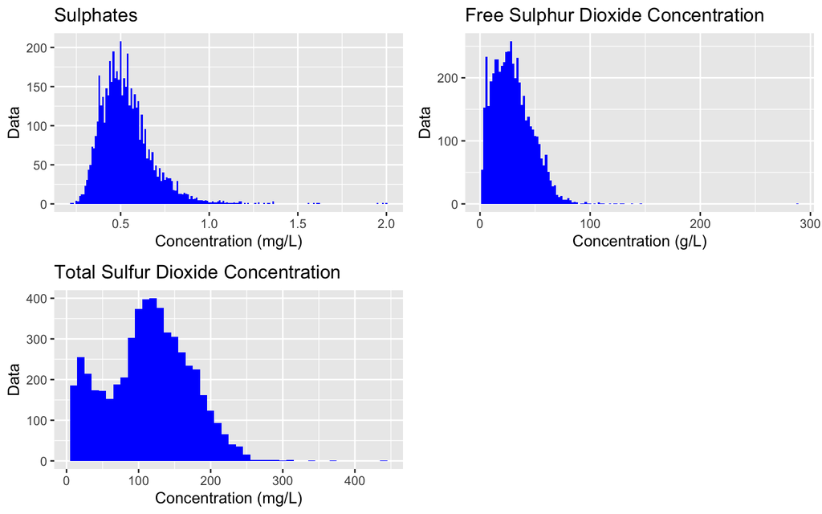

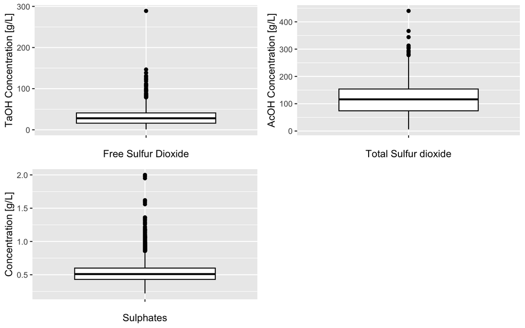

**Observations**

1. Free sulfur dioxide concentration is narrowly centered around 30 mg/L.
2. Total sulfur dioxide concentration shows signs of bimodality with peaks around 20 and 120 mg/L.
3. Most wines have a sulphate concentration around 0.5 g/L. Two small outlier groups around 1.6 and 1.9 g/L can be seen in the boxplot.

### **4. Sugar, Alcohol, Density, Chlorides Plots**

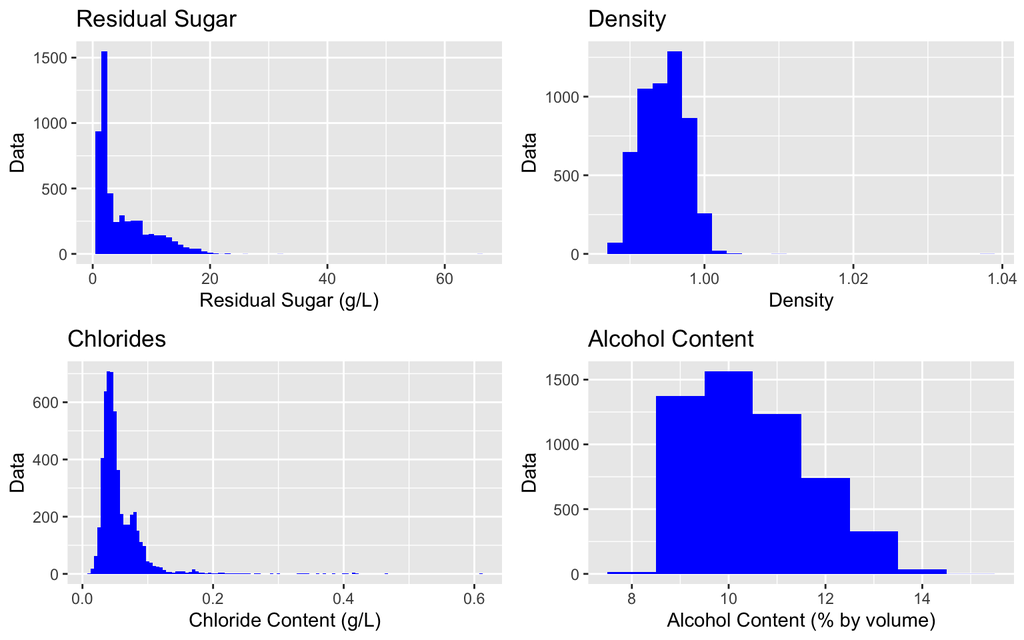

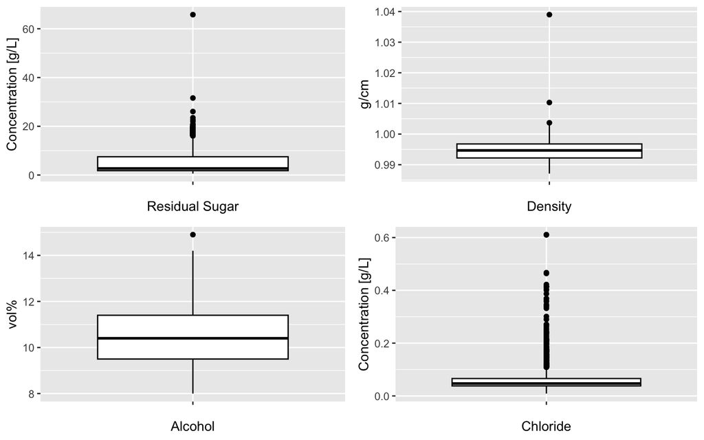

## Correlation Matrix

Before, we get into further detailed analysis we want to see which are the the variables which significantly influence the quality of the wines. For this we have done a correlation matrix.

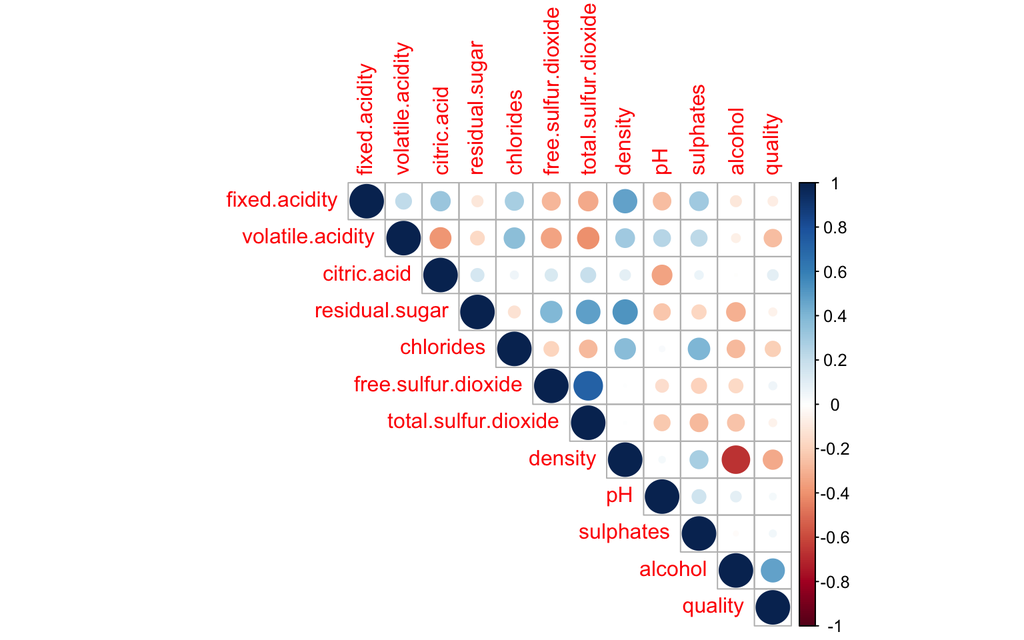

Our target variable is **Quality** and hence, we will explore the variables that are most correlated with Quality.

## Bivariate Analysis

### **1. Alcohol vs Quality**

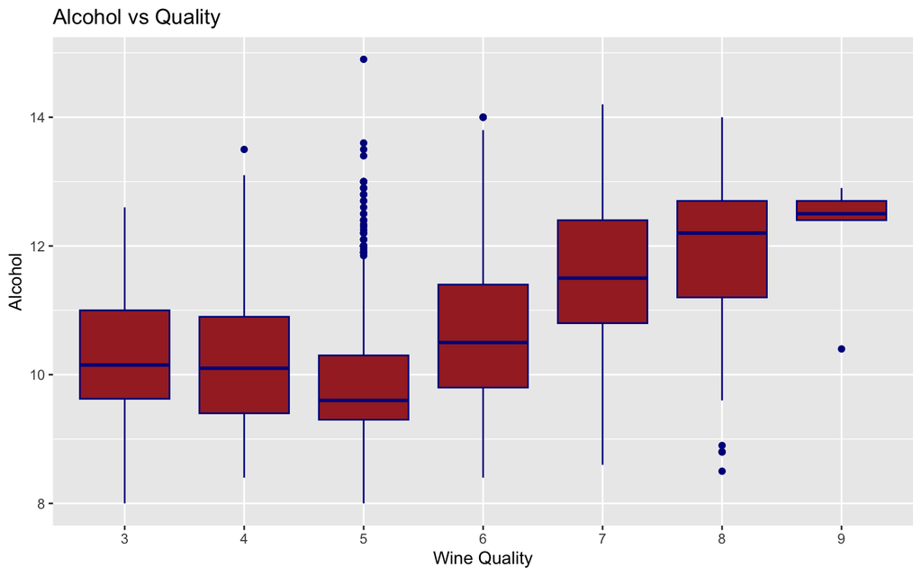

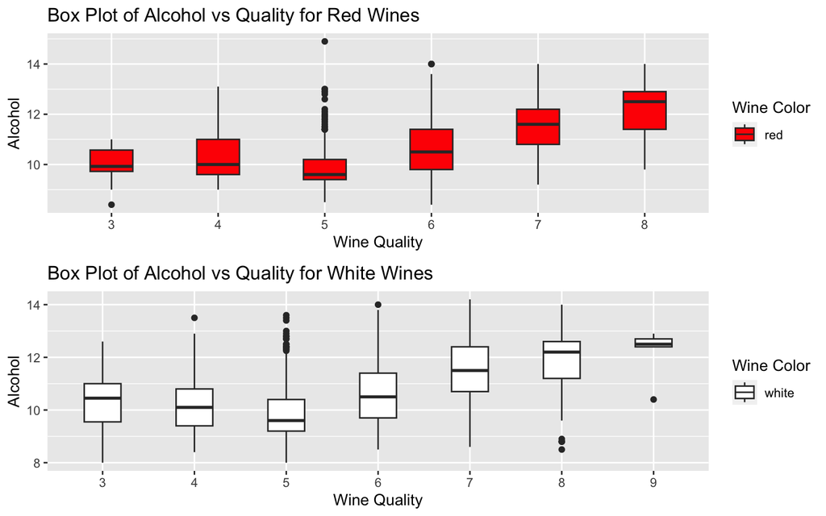

**Observations**

1. White Wines have **higher** alcohol content.
2. Alcohol has a **strong positive correlation** with quality.
3. The boxplot shows that wines with **higher quality** seem to have **higher alcohol content.**

### **2. Density vs Quality**

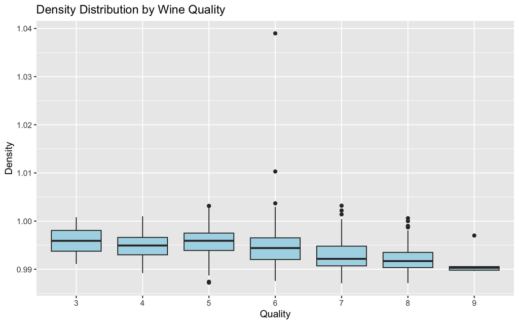

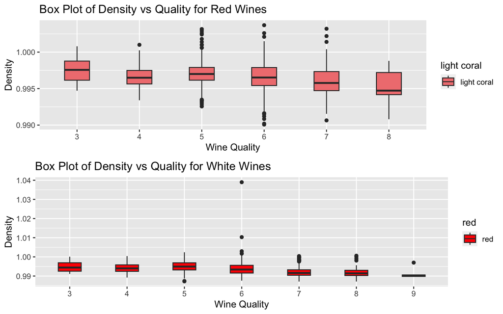

**Observations:**

1. Red Wines are **more dense** than white wines.
2. Density has a **negative correlation** with quality.
3. The boxplot shows that wines with **higher quality** seem to be **less dense.**

### **3. Chlorides vs Quality**

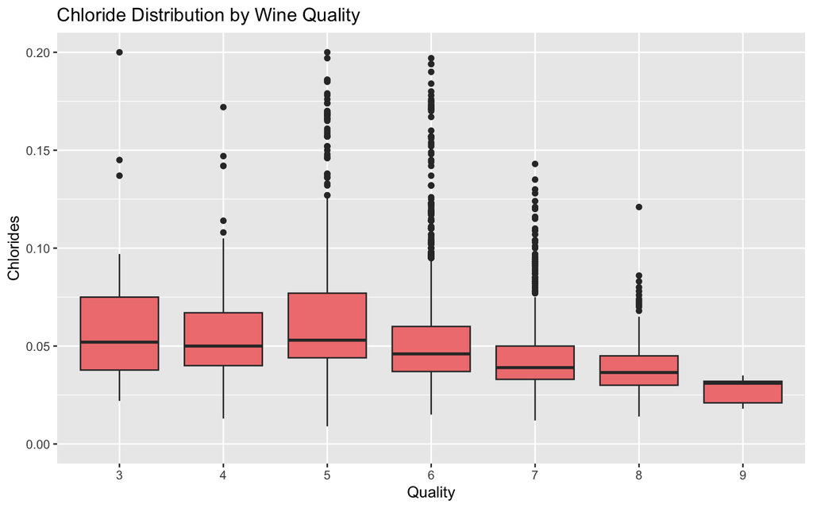

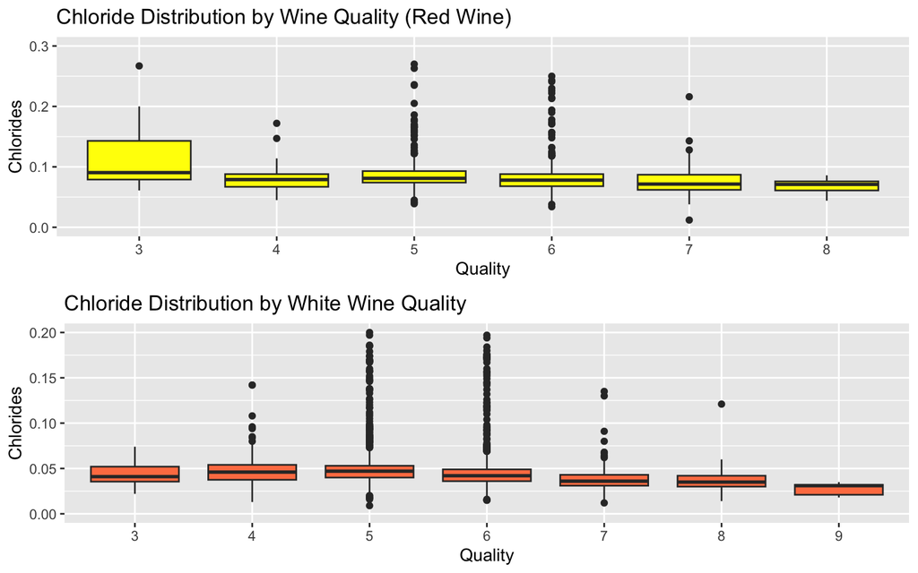

**Observations:**

1. Red Wines have more chloride concentration than white wines.
2. Chloride Concentration has a **slight negative correlation** with quality
3. The boxplot shows that wines with **higher quality** seem to have **less chlorides.**

### **4. Citric Acid vs Quality**

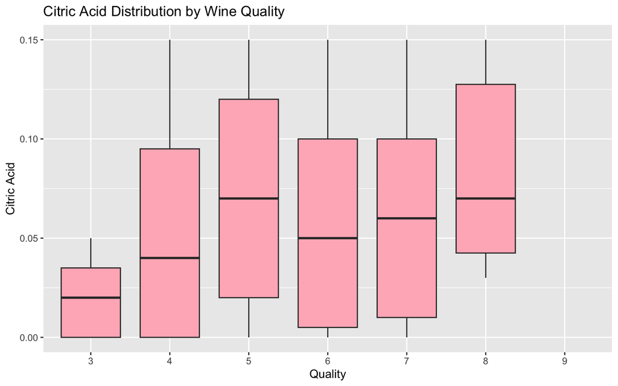

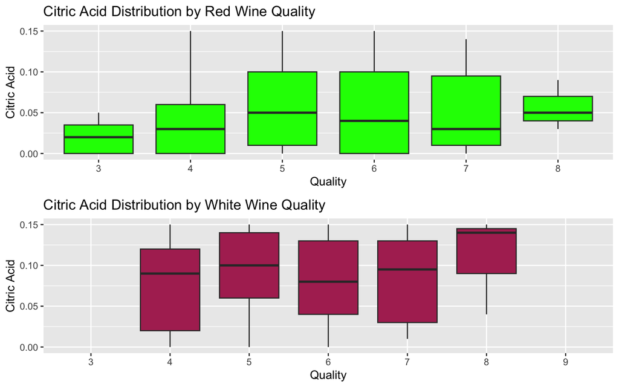

**Observations:**

1. White Wines have more citric acid concentration than red wines.
2. Citric Acid Concentration has a **slight positive correlation** with quality.
3. There isn’t much difference in citric acid concentration in white wines across the quality ratings.
4. The boxplot shows that wines with **higher quality** seem to have a **high citric acid.**

## Multivariate Analysis

For the last part of our EDA, we will perform some multivariate plots to see some how the other non-important features in wine are distributed in red and white wine.

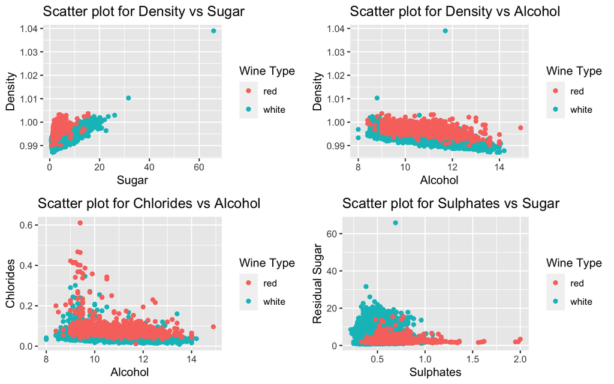

**Observations:**

1. White Wines have more sugar concentration than red wines. This might explain why white wines are usually sweeter.
2. Red wines contain high chloride and sulphate concentrations.

## Statistical Tests

We have performed a few statistical tests to support our analysis.

### **1. Alcohol vs Quality**

**WELCH TWO SAMPLE T-TEST:**

NULL HYPOTHESIS (H0): There is no significant mean difference between red and white wine in alcohol content.

ALTERNATE HYPOTHESIS (H1): There is significant mean difference between the two wines.

We found that the **p-value : 3.606^{-6}** is less than 0.05, we **reject the null hypothesis** and conclude that there is a significant difference in mean alcohol concentration between red and white wine.

**ANOVA TEST FOR RED AND WHITE WINE:**

NULL HYPOTHESIS (H0): There is no significant difference in mean alcohol content across quality categories in red wine/white wine.

ALTERNATE HYPOTHESIS (H1): There is significant difference in mean alcohol content across quality categories in red wine/white wine

We carried out separate tests for each wine and we found that the p-value for both red and white wine are less that 0.05, we **reject the null hypothesis** and conclude that there is a significant difference in mean alcohol content across all categories of both the wine.

### **2. Density vs Quality**

**WELCH TWO SAMPLE T-TEST:**

NULL HYPOTHESIS (H0): There is no substantial mean density difference between red and white wine.

ALTERNATE HYPOTHESIS (H1): The two wines have a considerable mean difference.

We found that the **p-value : 7^{-322}** is less than 0.05, we **reject the null hypothesis** and conclude that there is a significant difference in mean density concentration between red and white wine.

**RED AND WHITE WINE ANOVA TEST:**

NULL HYPOTHESIS (H0): There is no significant variation in mean density between red wine and white wine quality groups.

ALTERNATE HYPOTHESIS (H1): There is a considerable difference in mean density between red wine and white wine quality groups.

We carried out separate ANOVA tests for each wine and we found that the p-value for both red and white wine are less that 0.05, we **reject the null hypothesis** and conclude that there is a significant difference in mean density content across all categories of both the wine.

### **3. Chloride vs Quality**

**WELCH TWO SAMPLE T-TEST:**

NULL HYPOTHESIS (H0): There is no significant mean difference in chloride concentration between red and white wine.

ALTERNATE HYPOTHESIS (H1): There is a significant mean difference between the two wines.

We found that the **p-value : 3.706^{-159}** is less than 0.05, we **reject the null hypothesis** and conclude that there is a significant difference in mean chloride concentration between red and white wine.

**ANOVA TEST FOR RED AND WHITE WINE:**

NULL HYPOTHESIS (H0): There is no significant difference in mean chloride concentration across quality categories in red wine/white wine.

ALTERNATE HYPOTHESIS (H1): There is a significant difference in mean chloride concentration across quality categories in red wine/white wine.

We carried out separate ANOVA tests for each wine and we found that the p-value for both red and white wine are less that 0.05, we **reject the null hypothesis** and conclude that there is a significant difference in mean chloride content across all categories of both the wine.

### **4. Citric acid vs Quality**

**WELCH TWO SAMPLE T-TEST:**

NULL HYPOTHESIS (H0): There is no significant mean difference in citric acid content between red and white wine.

ALTERNATE HYPOTHESIS (H1): There is a significant mean difference between the two wines.

We found that the **p-value: 1.335^{-26}** is less than 0.05, we **reject the null hypothesis** and conclude that there is a significant difference in mean citric acid concentration between red and white wine.

**ANOVA TEST FOR RED AND WHITE WINE:**

NULL HYPOTHESIS (H0): There is no significant difference in mean citric acid content across quality categories in red wine/white wine.

ALTERNATE HYPOTHESIS (H1): There is a significant difference in mean citric acid content across quality categories in red wine/white wine.

We carried out separate tests for each wine and we found that the p-value for red is less than 0.05, where as for the white wine the p value is greater than 0.05, Hence we **reject the null hypothesis** for red wine only and concluded that there is a significant difference in mean citric content in red wine.

## Results

1. Wines with **higher alcohol content, increased citric acid levels, lower density, and less chlorides** tend to exhibit **higher quality**.
2. It appears that **white wines**, in general, tend to be **sweeter** and have **higher alcohol content** when compared to their red counterparts.
3. **Red Wines** have *more* concentration of **sulphates and chlorides**.

## Limitations of the Dataset

Although we thoroughly believe in our analysis, we have to mention a few anomalies that are present that may or may not have influenced the results.

1. The number of data that we have on white wine is comparatively more than that of red wine.
2. We have also observed that most of the data present are in the average quality range i.e, from 4-8.

For a better analysis, we need a more balanced data.

## Conclusions

Through our exploration of wine quality we have come across some discoveries that challenge wine making beliefs. While **alcohol content, sugar levels and acidity** are known factors we have found that attributes, like **density and chlorides** also play roles in shaping the quality of wine. These elements contribute in ways that captivate our senses and define what truly makes a bottle of wine.

Moreover we have delved into the contrast between white wines going beyond mere color differences to uncover deeper variations in chemical composition and sensory profiles. By understanding these distinctions we empower wine enthusiasts and consumers to make choices based on their personal preferences and specific occasions. With the support of tests such as the **T Test** to check if there is a *significant difference between the factors for red nd white wine* and **ANOVA Tests** to find how these factors *vary across different quality ratings in red and white wine* our findings are substantiated by evidence establishing a strong framework for comprehending the intricate interplay of variables that influence wine quality.

Equipped with this knowledge let us raise our glasses to the fusion of data science and wine making artistry. We also hope that one uses this knowledge to buy great wines.

## Additional Insights

Even if our present investigation has been fascinating, we understand that the quest to predict wine quality is a dynamic endeavour. Our commitment to gaining deeper insights is demonstrated by our efforts to include a wider range of attributes that affect wine quality to our dataset. This growth is a calculated step towards a more comprehensive knowledge of the complex process of wine making, not just an increase in data. We want to build a predictive model that goes into the nuances of winemaking and captures every detail that contributes to wine greatness by incorporating a wider variety of variables.

We hope to improve our predictive model in this ongoing investigation to deliver even more thorough and accurate results.

## References

We have included necessary citation for the data set from:

1. Cortez, P., Teixeira, J., Cerdeira, A., Almeida, F., Matos, T., Reis, J. (2009). Using Data Mining for Wine Quality Assessment. In: Gama, J., Costa, V.S., Jorge, A.M., Brazdil, P.B. (eds) Discovery Science. DS 2009. Lecture Notes in Computer Science(), vol 5808. Springer, Berlin, Heidelberg. https://doi.org/10.1007/978-3-642-04747-3_8
2. https://www.kaggle.com/datasets/yasserh/wine-quality-dataset/data
3. https://link.springer.com/chapter/10.1007/978-3-642-04747-3_8